# ps05-code-czahn2

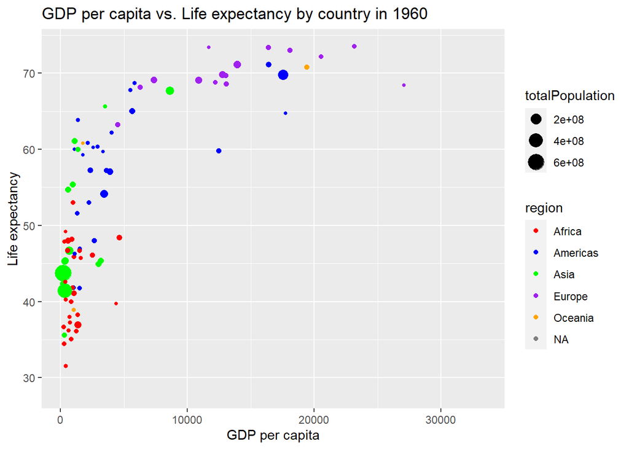

```r
gapminder_1960 <- filter(gapminder, time == 1960)

ggplot(gapminder_1960, aes(x = GDP_PC, y = lifeExpectancy, size = totalPopulation, col = region)) +
  geom_point() +
  scale_color_manual(values = c("red", "blue", "green", "purple", "orange", "brown")) +
  labs(title = "GDP per capita vs. Life expectancy by country in 1960", x = "GDP per capita", y = "Life expectancy")
```

```r
## As GDP increases, life expectancy also tends to increase. The countries with small GPD and LE are mostly in Africa or Asia,
## and the countries with large GDP and LE are mostly in the Americas or Europe.
```

2. (4pt) Make a similar plot, but this time use 2019 data only.

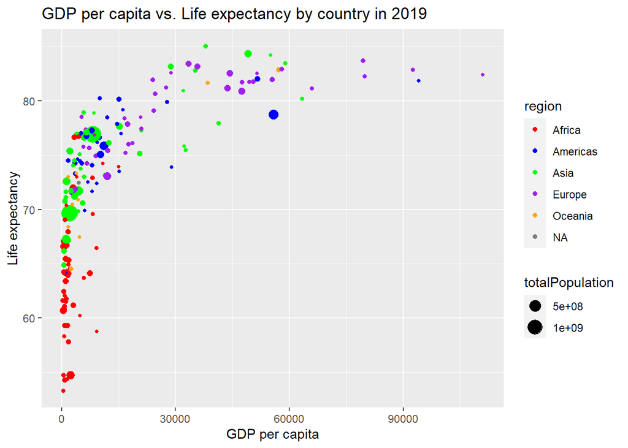

```r
gapminder_2019 <- filter(gapminder, time == 2019)

ggplot(gapminder_2019, aes(x = GDP_PC, y = lifeExpectancy, size = totalPopulation, col = region)) +
  geom_point() +
  scale_color_manual(values = c("red", "blue", "green", "purple", "orange", "brown")) +
  labs(title = "GDP per capita vs. Life expectancy by country in 2019", x = "GDP per capita", y = "Life expectancy")
```

3. (6pt) Compare these two plots and comment what do you see. How has world developed through the last 60 years?

```r
## The biggest difference i see in the plots is that many more Asian countries have higher GDP and LE in 2019.
## Every continent has increased, but Asia stands out to me the most.
```

4. (6pt) Compute the average life expectancy for each continent in 1960 and 2019. Do the results fit with what do you see on the figures? Note: here as average I mean just average over countries, ignore the fact that countries are of different size.

```r
gapminder_1960 %>%
  group_by(region) %>%
  filter(!is.na(lifeExpectancy)) %>%
  summarize(mean = mean(lifeExpectancy))
```

```
## # A tibble: 6 × 2
##   region    mean
##   <chr>    <dbl>
## 1 Africa    41.5
## 2 Americas  58.6
## 3 Asia      51.6
## 4 Europe    68.3
## 5 Oceania   56.4
## 6 <NA>      70.7
```

```r
gapminder_2019 %>%
  group_by(region) %>%
  filter(!is.na(lifeExpectancy)) %>%
  summarize(mean = mean(lifeExpectancy))
```

```
## # A tibble: 6 × 2
##   region    mean
##   <chr>    <dbl>
## 1 Africa    64.1
## 2 Americas  75.8
## 3 Asia      74.6
## 4 Europe    79.4
## 5 Oceania   73.5
## 6 <NA>      77.8
```

```r
##Yes, average LE increased significantly for every continent between 1960-2019.
```

5. (8pt) Compute the average LE growth from 1960-2019 across the continents. Show the results in the order of growth. Explain what do you see. Hint: these data (data in long form) is not the simplest to compute growth. But you may want to check out the lag() function. And do not forget to group data by continent when using lag(), otherwise your results will be messed up! See https://faculty.washington. edu/otoomet/info201-book/dplyr.html#dplyr-helpers-compute.

```r
gapminder %>%
  group_by(region) %>%
  arrange(name, time) %>%
  mutate(avg_le = (lifeExpectancy - lag(lifeExpectancy)) / lag(lifeExpectancy)) %>%
  filter(time >= 1961) %>%
  summarize(avg_growth = mean(avg_le, na.rm = TRUE)) %>%
  arrange(avg_growth)
```

```
## # A tibble: 6 × 2
##   region   avg_growth
##   <chr>         <dbl>
## 1 Europe      0.00255
## 2 Americas    0.00437
## 3 Oceania     0.00463
## 4 Asia        0.00650
## 5 Africa      0.00746
## 6 <NA>        0.0551
```

6. (6pt) Show the histogram of GDP per capita for years of 1960 and 2019. Try to put both histograms on the same graph, see how well you can do it!

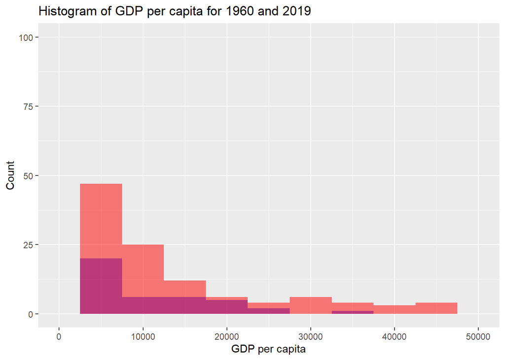

```r
ggplot() +
 geom_histogram(data = gapminder_1960, aes(x = GDP_PC),
                 binwidth = 5000, fill = "blue", alpha = 0.5) +
geom_histogram(data = gapminder_2019, aes(x = GDP_PC),
                 binwidth = 5000, fill = "red", alpha = 0.5) +
  xlab("GDP per capita") +
  ylab("Count") +
  ggtitle("Histogram of GDP per capita for 1960 and 2019") +
  scale_fill_manual(values = c("blue", "red"),
                    labels = c("1960", "2019"),
                    name = "Year") +
  # Set axis limits to zoom in on the data
  xlim(0, 50000) +
  ylim(0, 100)
```

7. (6pt) What was the ranking of US in terms of life expectancy in 1960 and in 2019? (When counting from top.) Hint: check out the function rank()! Hint2: 17 for 1960.

```r
gapminder_ranked <- gapminder %>%
  filter(!is.na(time), !is.na(name)) %>%
  group_by(time, name) %>%
  mutate(rank = rank(desc(lifeExpectancy)))

us_rank_1960 <- gapminder_ranked %>%
  filter(time == 1960 & name == "United States") %>%
  pull(rank)

us_rank_2019 <- gapminder_ranked %>%
  filter(time == 2019 & name == "United States") %>%
  pull(rank)

# Print results
cat("Ranking of US in 1960:", us_rank_1960, "\n")
```

```
## Ranking of US in 1960:
```

```r
cat("Ranking of US in 2019:", us_rank_2019, "\n")
```

```
## Ranking of US in 2019:
```

Comment: I couldn’t get this one to function correctly :( Dont know why it won’t print the ranking.

8. (6pt) If you did this correctly, then you noticed that US ranking has been falling quite a bit. But we also have more countries in 2019–what about the relative rank divided by the corresponding number of countries that have LE data in the corresponding year? Hint: 0.0904 for 1960.

```r
# calculate relative rank for 1960
gapminder_1960 %>%
  mutate(rank = rank(desc(lifeExpectancy))) %>%
  filter(name == "USA")
```

```
## # A tibble: 0 × 26
## # … with 26 variables: iso3 <chr>, name <chr>, iso2 <chr>, region <chr>,
## #   sub-region <chr>, intermediate-region <chr>, time <dbl>,
## #   totalPopulation <dbl>, fertilityRate <dbl>, lifeExpectancy <dbl>,
## #   childMortality <dbl>, youthFemaleLiteracy <dbl>, youthMaleLiteracy <dbl>,
## #   adultLiteracy <dbl>, GDP_PC <dbl>, accessElectricity <dbl>,
## #   agriculturalLand <dbl>, agricultureTractors <dbl>, cerealProduction <dbl>,
## #   fertilizerHa <dbl>, co2 <dbl>, greenhouseGases <dbl>, co2_PC <dbl>, …
```

```r
rank_1960 <- gapminder_1960$rank / n_distinct(gapminder$name[gapminder$time == 1960])
# calculate relative rank for 2019
gapminder_2019 %>%
  mutate(rank = rank(desc(lifeExpectancy))) %>%
  filter(name == "USA")
```

```
## # A tibble: 0 × 26
## # … with 26 variables: iso3 <chr>, name <chr>, iso2 <chr>, region <chr>,
## #   sub-region <chr>, intermediate-region <chr>, time <dbl>,
## #   totalPopulation <dbl>, fertilityRate <dbl>, lifeExpectancy <dbl>,
## #   childMortality <dbl>, youthFemaleLiteracy <dbl>, youthMaleLiteracy <dbl>,
## #   adultLiteracy <dbl>, GDP_PC <dbl>, accessElectricity <dbl>,
## #   agriculturalLand <dbl>, agricultureTractors <dbl>, cerealProduction <dbl>,
## #   fertilizerHa <dbl>, co2 <dbl>, greenhouseGases <dbl>, co2_PC <dbl>, …
```

```r
rank_2019 <- gapminder_2019$rank / n_distinct(gapminder$name[gapminder$time == 2019])
# print results
cat("Relative rank of the US in terms of life expectancy in 1960:",
    round(rank_1960, 2), "\n")
```

```
## Relative rank of the US in terms of life expectancy in 1960:
```

```r
cat("Relative rank of the US in terms of life expectancy in 2019:",
    round(rank_2019, 2), "\n")
```

```
## Relative rank of the US in terms of life expectancy in 2019:
```

Comment: I couldn’t get this one to function correctly :( Dont know why it won’t print the ranking.

I spent 10 hours on this PS.